# R语言与数据可视化

小天使格礼

# 前言

数据可视化是数据分析中最直观、最有效的沟通方式。一张好的图表胜过千言万语，能够帮助我们发现数据中的模式、趋势和异常。R语言拥有强大的可视化生态系统，从基础绘图到现代的ggplot2，从静态图表到交互式可视化，应有尽有。

本教程将系统介绍R语言数据可视化的各项技术，帮助你创建专业、美观、有效的数据可视化作品。

本教程的建议学习方法：先阅读并理解前四章内容即可，后面的内容可以在需要使用的时候再看，但依然建议粗略浏览以获得大致印象

本教程涵盖以下内容：

### 第一章：R语言可视化概述与基础绘图系统

| 小节 | 内容 | 链接 |
| --- | --- | --- |
| 1.1 | R可视化生态系统简介 | 概述 |
| 1.2 | 基础绘图系统核心思想 | 画家模式 |
| 1.3 | 高级绘图函数 | plot/hist/boxplot/barplot |
| 1.4 | 低级绘图函数 | points/lines/text/legend |
| 1.5 | 图形参数设置 | par()参数 |
| 1.6 | 基础图形布局 | layout()布局 |
| 1.7 | 保存基础图形 | pdf/png/jpeg |
| 1.8 | 基础绘图的局限性与转型至ggplot2 | 转型建议 |

### 第二章：ggplot2绘图语法基础

| 小节 | 内容 | 链接 |
| --- | --- | --- |
| 2.1 | ggplot2的安装与加载 | 入门 |
| 2.2 | 图形语法核心理念 | 图层概念 |
| 2.3 | ggplot()函数与数据映射 | aes()映射 |
| 2.4 | 几何对象 | geom_*函数 |
| 2.5 | 统计变换 | stat_*变换 |
| 2.6 | 标度概述 | scale_*标度 |
| 2.7 | 坐标系概述 | coord_*坐标系 |
| 2.8 | 分面概述 | facet_*分面 |
| 2.9 | 主题概述 | theme()主题 |
| 2.10 | 使用+符号构建图形 | 图层叠加 |

### 第三章：常用统计图形（基础）

| 小节 | 图形类型 | 链接 |
| --- | --- | --- |
| 3.1 | 散点图 | geom_point() |
| 3.2 | 折线图 | geom_line() |
| 3.3 | 柱状图 | geom_bar()/geom_col() |
| 3.4 | 直方图 | geom_histogram() |
| 3.5 | 密度图 | geom_density() |
| 3.6 | 箱线图 | geom_boxplot() |
| 3.7 | 小提琴图 | geom_violin() |
| 3.8 | 点图 | geom_dotplot() |
| 3.9 | 面积图 | geom_area() |
| 3.10 | 饼图 | coord_polar() |
| 3.11 | 误差条 | geom_errorbar() |
| 3.12 | 平滑曲线 | geom_smooth() |
| 3.13 | 分位图 | geom_quantile() |
| 3.14 | 文本注释 | geom_text()/geom_label() |
| 3.15 | 热图 | geom_tile() |

### 第四章：图形属性与标度调整

| 小节 | 内容 | 链接 |
| --- | --- | --- |
| 4.1 | 颜色标度 | scale_color_* |
| 4.2 | 形状标度 | scale_shape_* |
| 4.3 | 大小标度 | scale_size_* |
| 4.4 | 线条类型标度 | scale_linetype_* |
| 4.5 | 透明度标度 | scale_alpha_* |
| 4.6 | 坐标轴标度 | scale_x/y_* |
| 4.7 | 日期轴标度 | scale_x_date() |
| 4.8 | 手动设定标度 | scale_*_manual() |
| 4.9 | 坐标轴变换 | scale_*_log10/trans |
| 4.10 | 图例与标题的调整 | guides()/labs() |

### 第五章：坐标系与分面

| 小节 | 内容 | 链接 |
| --- | --- | --- |
| 5.1 | 笛卡尔坐标系 | coord_cartesian() |
| 5.2 | 固定纵横比 | coord_fixed() |
| 5.3 | 极坐标系 | coord_polar() |
| 5.4 | 翻转坐标系 | coord_flip() |
| 5.5 | 地图投影 | coord_map() |
| 5.6 | 分面基础：facet_wrap | 一维分面 |
| 5.7 | 分面进阶：facet_grid | 二维分面 |
| 5.8 | 分面中的标度自由设定 | scales参数 |
| 5.9 | 分面标签与间距调整 | labeller参数 |
| 5.10 | 嵌套分面 | facet_nested() |

### 第六章：主题系统与图形定制

| 小节 | 内容 | 链接 |
| --- | --- | --- |
| 6.1 | 内置主题 | theme_bw/gray/minimal |
| 6.2 | 主题元素调整 | element_*函数 |
| 6.3 | 文本元素 | element_text() |
| 6.4 | 矩形元素 | element_rect() |
| 6.5 | 线条元素 | element_line() |
| 6.6 | 图例位置与样式 | legend.position |
| 6.7 | 间距与边距 | margin/plot.margin |
| 6.8 | 自定义完整主题 | theme()函数 |
| 6.9 | 扩展包主题 | ggthemes/hrbrthemes |

### 第七章：多图组合与排版

| 小节 | 内容 | 链接 |
| --- | --- | --- |
| 7.1 | 基础多图：par(mfrow) | 基础方法 |
| 7.2 | 网格布局：gridExtra | grid.arrange() |
| 7.3 | cowplot包 | plot_grid() |
| 7.4 | patchwork包 | +/\|操作符 |
| 7.5 | 插入子图 | inset plot |
| 7.6 | 共用图例与轴 | get_legend() |
| 7.7 | 复杂布局设计 | area()布局 |
| 7.8 | 多页PDF输出 | pdf()设备 |

### 第八章：颜色、字体与标注的精细控制

| 小节 | 内容 | 链接 |
| --- | --- | --- |
| 8.1 | RColorBrewer调色板 | 配色方案 |
| 8.2 | viridis色系 | 色盲友好配色 |
| 8.3 | 自定义颜色向量 | colorRampPalette() |
| 8.4 | 渐变色自定义 | scale_*_gradient() |
| 8.5 | 字体设置 | showtext包 |
| 8.6 | 使用系统字体 | extrafont包 |
| 8.7 | 标注与文本注释的高级用法 | annotate()/geom_text() |
| 8.8 | 数学表达式与公式标注 | expression() |
| 8.9 | 表格嵌入图形 | gridExtra/tableGrob |

### 第九章：交互式可视化

| 小节 | 内容 | 链接 |
| --- | --- | --- |
| 9.1 | plotly包基础 | ggplotly() |
| 9.2 | plotly原生语法 | plot_ly() |
| 9.3 | 悬停信息定制 | tooltip定制 |
| 9.4 | 缩放、平移、框选交互 | 交互模式 |
| 9.5 | highcharter包 | 高级交互图表 |
| 9.6 | echarts4r包 | ECharts绑定 |
| 9.7 | ggiraph包 | 交互式ggplot |
| 9.8 | shiny中的可视化集成 | 动态可视化 |
| 9.9 | 交互式时间序列 | dygraphs包 |
| 9.10 | 交互式网络图 | visNetwork包 |

### 第十章：高级图表类型

| 小节 | 图形类型 | 链接 |
| --- | --- | --- |
| 10.1 | 统计分布图 | geom_density_ridges() |
| 10.2 | 二维密度图 | geom_density_2d() |
| 10.3 | 六边形热图 | geom_hex() |
| 10.4 | 韦恩图/欧拉图 | VennDiagram/eulerr |
| 10.5 | 词云 | wordcloud包 |
| 10.6 | 雷达图/蜘蛛图 | fmsb包 |
| 10.7 | 平行坐标图 | GGally包 |
| 10.8 | 瀑布图 | waterfalls包 |
| 10.9 | 相关系数矩阵图 | corrplot包 |
| 10.10 | 热图聚类 | pheatmap包 |
| 10.11 | 树状图 | ggdendro包 |
| 10.12 | 时间序列分解图 | forecast包 |
| 10.13 | 生存曲线图 | survminer包 |
| 10.14 | 森林图 | forestplot包 |

### 第十一章：动态可视化与动画

| 小节 | 内容 | 链接 |
| --- | --- | --- |
| 11.1 | gganimate基础 | transition_*函数 |
| 11.2 | 过渡效果 | transition_states() |
| 11.3 | 出现与消失 | enter/exit函数 |
| 11.4 | 视图过渡 | view_*函数 |
| 11.5 | 影子效果 | shadow_*函数 |
| 11.6 | 缓动函数 | ease_aes() |
| 11.7 | tweenr平滑过渡 | 插值动画 |
| 11.8 | transformr几何变换 | 形状变换 |
| 11.9 | 动画渲染设置 | animate()参数 |
| 11.10 | 复杂动画案例 | 综合示例 |

### 第十二章：空间数据可视化（地图）

| 小节 | 内容 | 链接 |
| --- | --- | --- |
| 12.1 | sf包基础 | 简单要素 |
| 12.2 | ggplot2绘制简单地图 | geom_sf() |
| 12.3 | 从外部读取地图数据 | rnaturalearth/maps |
| 12.4 | 地图数据可视化 | 填充地图 |
| 12.5 | 分层地图 | 多图层叠加 |
| 12.6 | 交互式地图：leaflet | leaflet包 |
| 12.7 | 地图投影变换 | coord_sf() |
| 12.8 | 地理数据聚合 | 空间聚合 |

### 第十三章：网络与层次结构可视化

| 小节 | 内容 | 链接 |
| --- | --- | --- |
| 13.1 | igraph基础 | 网络对象创建 |
| 13.2 | ggraph网络图 | geom_edge_* |
| 13.3 | 节点与边的美学 | 节点/边样式 |
| 13.4 | 网络布局算法 | layout参数 |
| 13.5 | 层次结构树状图 | dendrogram |
| 13.6 | 树状图定制 | ggraph树图 |

### 第十四章：模型诊断与统计结果可视化

| 小节 | 图形类型 | 链接 |
| --- | --- | --- |
| 14.1 | 回归诊断图 | plot(lm) |
| 14.2 | 残差分析可视化 | 残差图 |
| 14.3 | 随机森林变量重要性图 | varImpPlot() |
| 14.4 | 混淆矩阵可视化 | confusionMatrix图 |
| 14.5 | ROC曲线与AUC | pROC包 |
| 14.6 | 生存曲线 | survfit()图 |
| 14.7 | 模型预测对比图 | 预测值vs实际值 |
| 14.8 | 贝叶斯模型后验分布图 | bayesplot包 |

### 第十五章：可视化性能优化与最佳实践

| 小节 | 内容 | 链接 |
| --- | --- | --- |
| 15.1 | 大数据集可视化策略 | 采样/聚合策略 |
| 15.2 | geom_point的透明度与光栅化 | 透明度优化 |
| 15.3 | 使用data.table预先聚合 | 数据预处理 |
| 15.4 | 图形保存格式选择 | 矢量/位图格式 |
| 15.5 | 分辨率与尺寸设置 | DPI设置 |
| 15.6 | 可视化配色原则 | 配色建议 |
| 15.7 | 图标题、轴标签的清晰性 | 标签规范 |
| 15.8 | 避免信息冗余与图表垃圾 | 简洁原则 |
| 15.9 | 可重复性：脚本化图形生成 | 自动化流程 |
| 15.10 | 自定义函数封装常用图形模板 | 函数封装 |

在Rstudio中安装本节课所有需要的包，运行以下指令：

```r
install.packages(c(
  "ggplot2", "dplyr", "tidyr",
  "gridExtra", "cowplot", "patchwork", "grid",
  "RColorBrewer", "viridis",
  "ggrepel",
  "quantreg", "broom",
  "plotly", "highcharter", "echarts4r", "ggiraph", "dygraphs",
  "gganimate", "gapminder", "tweenr", "transformr",
  "sf", "maps", "rnaturalearth",
  "igraph", "ggraph", "ggforce",
  "factoextra",
  "randomForest",
  "pROC",
  "survival", "survminer",
  "ggalluvial", "treemapify",
  "ggforce"
))
```

# 第一章：R语言可视化概述与基础绘图系统

R语言提供了两套主要的绘图系统：基础绘图系统（base graphics）和基于图形语法的ggplot2系统。本章介绍基础绘图系统，它是理解R可视化的起点。

## 1.1 R可视化生态系统简介

R语言拥有丰富的可视化包和工具。

```r
# R可视化的主要系统

# 1. 基础绘图系统（base graphics）
# R内置的绘图系统，简单直接
# 主要函数：plot()、hist()、boxplot()、barplot()等

# 2. lattice包
# 基于网格图形系统，适合多变量、多面板图形
# 主要函数：xyplot()、bwplot()、histogram()等

# 3. ggplot2包
# 基于图形语法（Grammar of Graphics），最流行的R可视化包
# 使用图层叠加的方式构建图形

# 4. 交互式可视化
# plotly：将ggplot2转为交互式
# highcharter：高级交互图表
# leaflet：交互式地图

# 5. 专用可视化
# 热图：pheatmap、ComplexHeatmap
# 网络图：igraph、ggraph
# 时间序列：forecast、dygraphs
```

**小结**：ggplot2是R可视化的主流选择，但基础绘图系统仍然重要。

## 1.2 基础绘图系统核心思想

基础绘图系统采用”画家模式”，逐步在画布上添加图形元素。

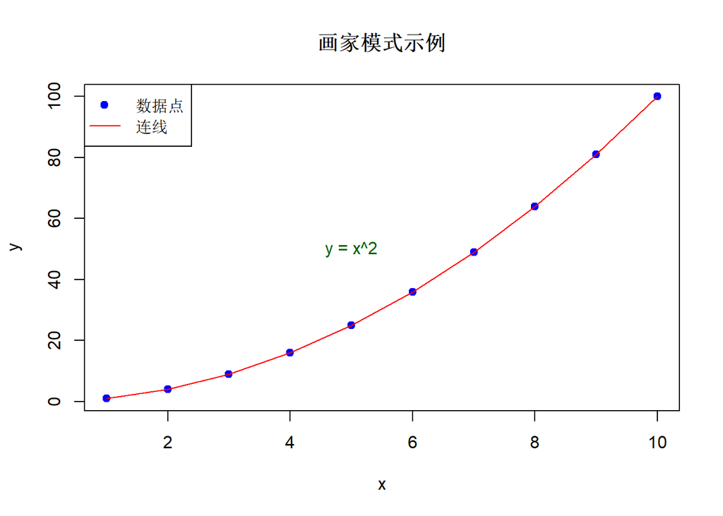

```r
# 基础绘图的两种函数类型

# 1. 高级绘图函数：创建新图形
# 每次调用会创建新的图形窗口
# 例如：plot()、hist()、boxplot()、barplot()

# 2. 低级绘图函数：在现有图形上添加元素
# 在当前图形上添加内容，不会创建新图形
# 例如：points()、lines()、text()、legend()

# 示例：画家模式
# 创建示例数据
x <- 1:10
y <- x^2

# 第一步：创建基础图形
plot(x, y, type = "n", main = "画家模式示例")  # type="n"只创建框架不画点

# 第二步：逐步添加元素
points(x, y, pch = 19, col = "blue")  # 添加点
lines(x, y, col = "red")              # 添加线
text(5, 50, "y = x^2", col = "darkgreen")  # 添加文本
legend("topleft", legend = c("数据点", "连线"),
       col = c("blue", "red"), pch = c(19, NA), lty = c(NA, 1))
```

**小结**：基础绘图系统像画家作画，逐步添加元素构建完整图形。

## 1.3 高级绘图函数

高级绘图函数创建新图形。

### plot()函数

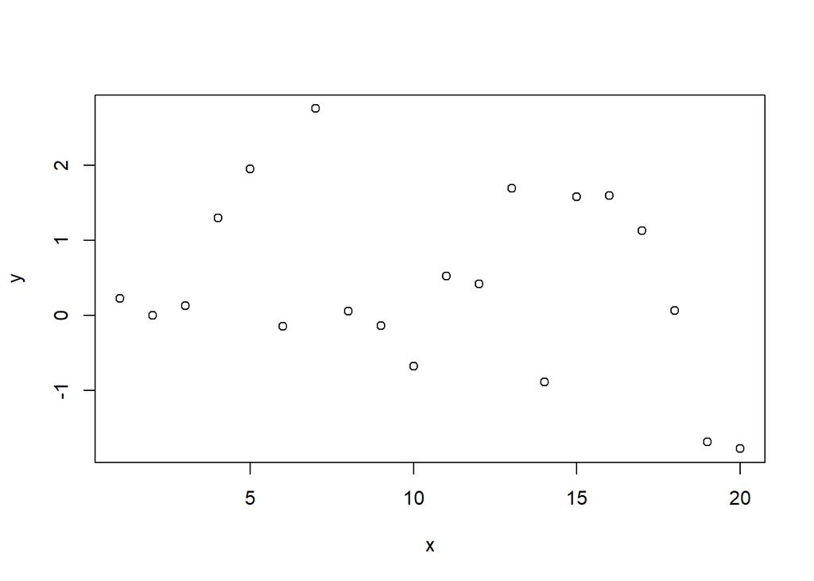

```r
# plot()是最通用的高级绘图函数

# 创建示例数据
x <- 1:20
y <- rnorm(20)

# 基础散点图
plot(x, y)
```

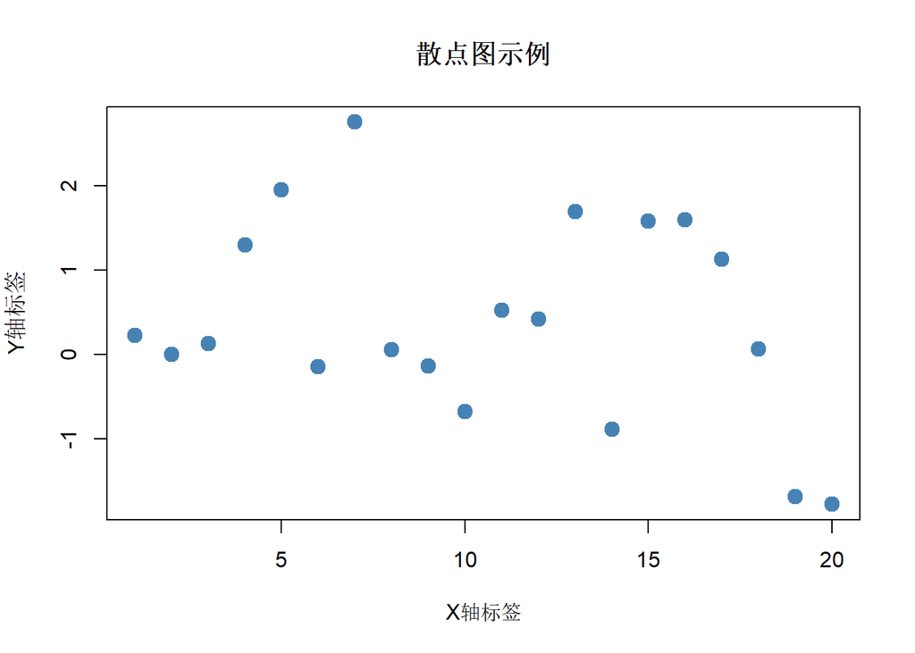

```r
# 指定标题和标签
plot(x, y,
     main = "散点图示例",      # 主标题
     xlab = "X轴标签",         # X轴标签
     ylab = "Y轴标签",         # Y轴标签
     col = "steelblue",        # 点的颜色
     pch = 19,                 # 点的形状（实心圆）
     cex = 1.5)                # 点的大小
```

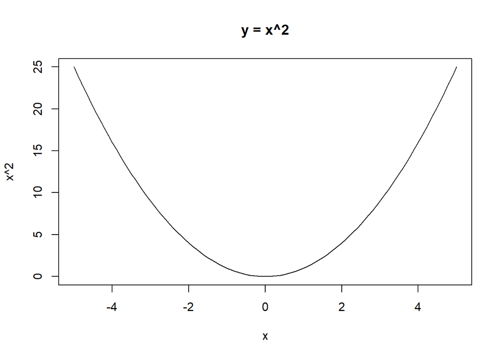

```r
# 绘制函数曲线
curve(x^2, from = -5, to = 5, main = "y = x^2")
```

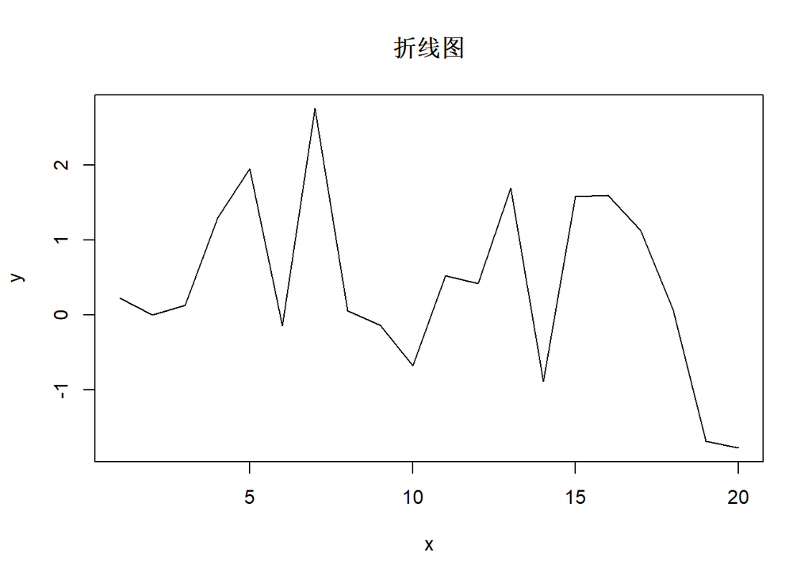

```r
# 绘制折线图
plot(x, y, type = "l", main = "折线图")  # type="l"表示线条
```

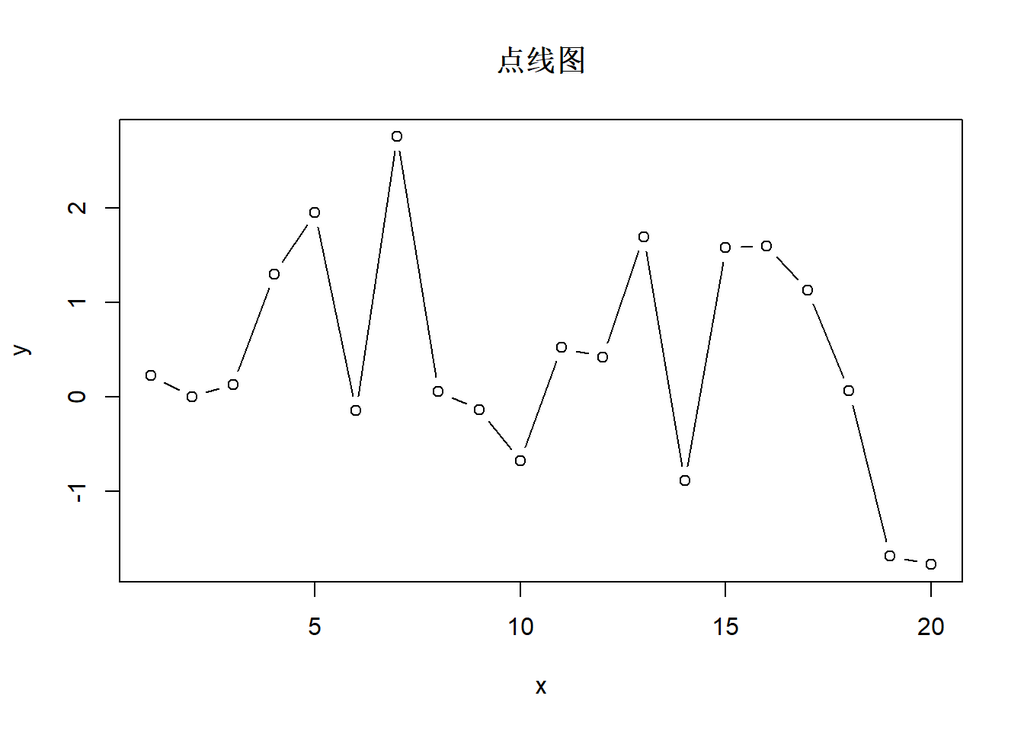

```r
# 绘制点线图
plot(x, y, type = "b", main = "点线图")  # type="b"表示点和线
```

### hist()函数

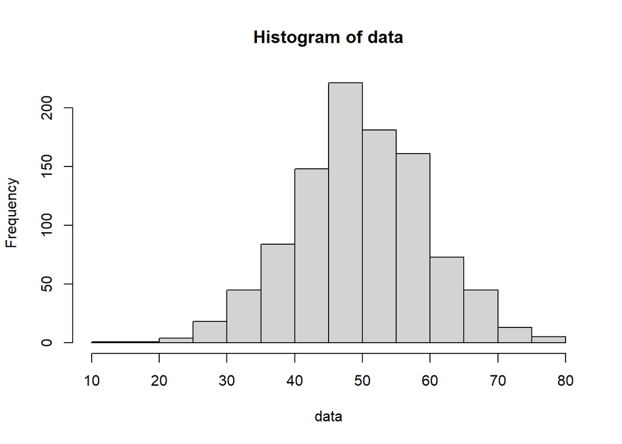

```r
# hist()绘制直方图

# 创建正态分布数据
data <- rnorm(1000, mean = 50, sd = 10)

# 基础直方图
hist(data)
```

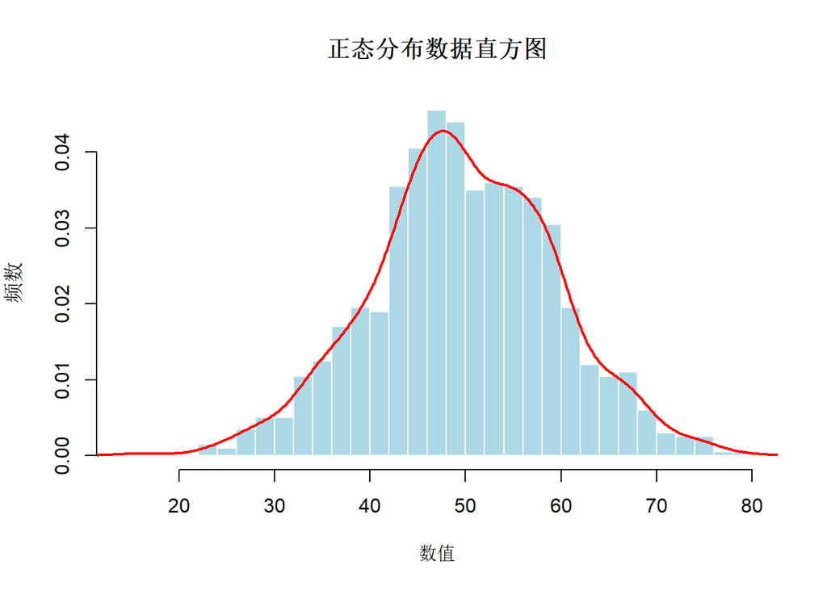

```r
# 自定义直方图
hist(data,
     main = "正态分布数据直方图",
     xlab = "数值",
     ylab = "频数",
     col = "lightblue",
     breaks = 30,              # 分组数量
     border = "white",         # 边框颜色
     probability = TRUE)       # 显示概率密度而非频数

# 添加密度曲线
lines(density(data), col = "red", lwd = 2)
```

### boxplot()函数

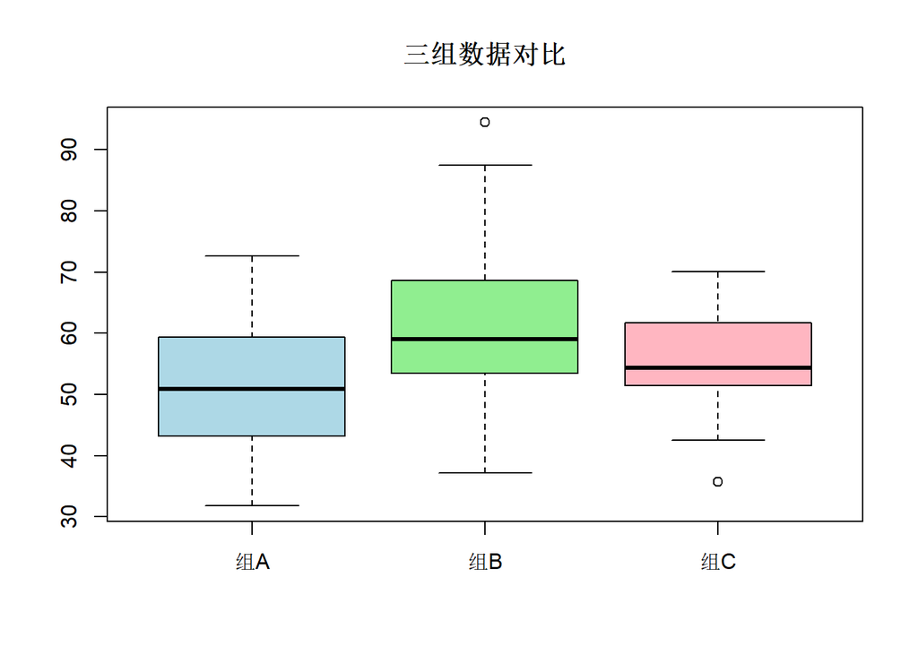

```r
# boxplot()绘制箱线图

# 创建分组数据
group_A <- rnorm(50, mean = 50, sd = 10)
group_B <- rnorm(50, mean = 60, sd = 15)
group_C <- rnorm(50, mean = 55, sd = 8)

# 基础箱线图
boxplot(group_A, group_B, group_C,
        main = "三组数据对比",
        names = c("组A", "组B", "组C"),
        col = c("lightblue", "lightgreen", "lightpink"))
```

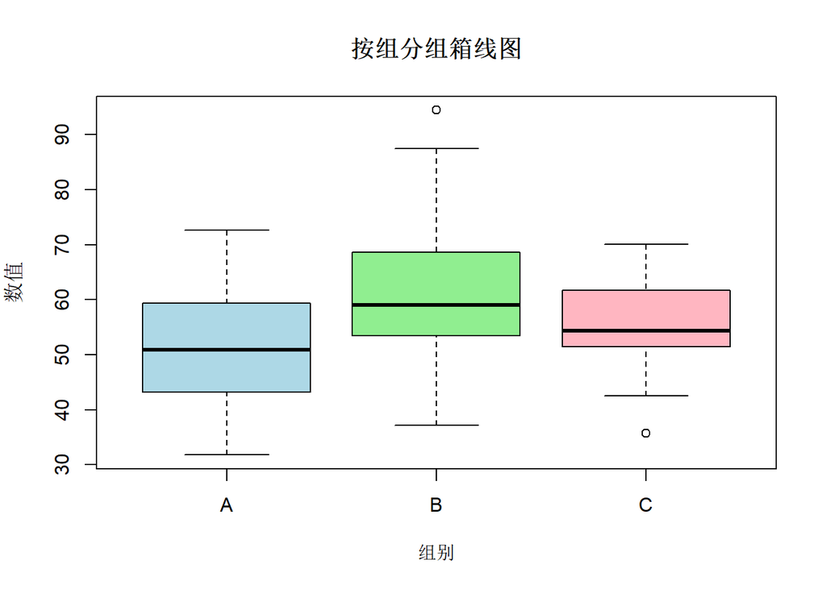

```r
# 使用公式语法
df <- data.frame(
  value = c(group_A, group_B, group_C),
  group = factor(rep(c("A", "B", "C"), each = 50))
)

boxplot(value ~ group, data = df,
        main = "按组分组箱线图",
        xlab = "组别",
        ylab = "数值",
        col = c("lightblue", "lightgreen", "lightpink"))
```

### barplot()函数

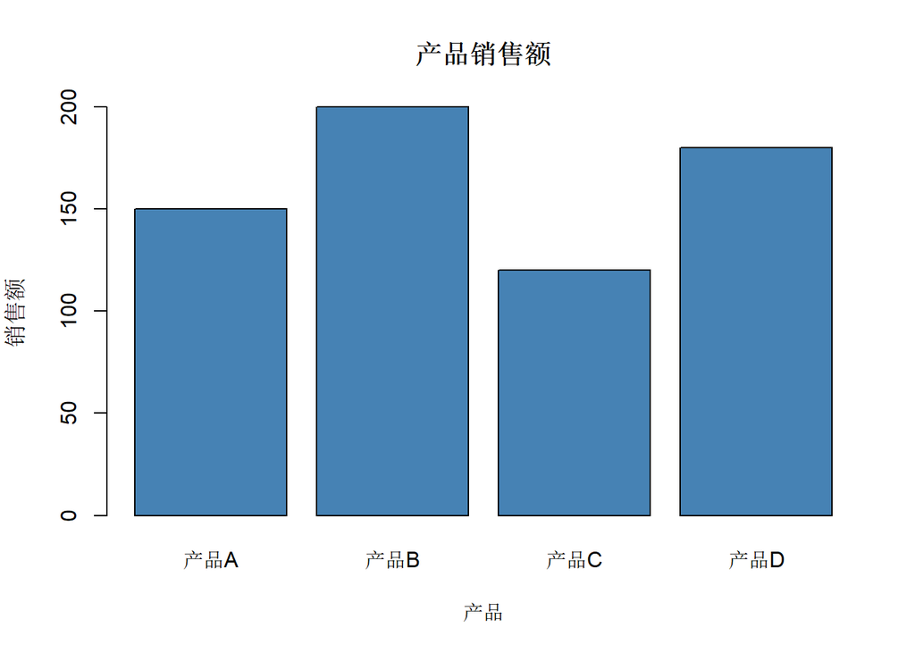

```r
# barplot()绘制柱状图

# 创建数据
categories <- c("产品A", "产品B", "产品C", "产品D")
sales <- c(150, 200, 120, 180)

# 基础柱状图
barplot(sales, names.arg = categories,
        main = "产品销售额",
        xlab = "产品",
        ylab = "销售额",
        col = "steelblue")
```

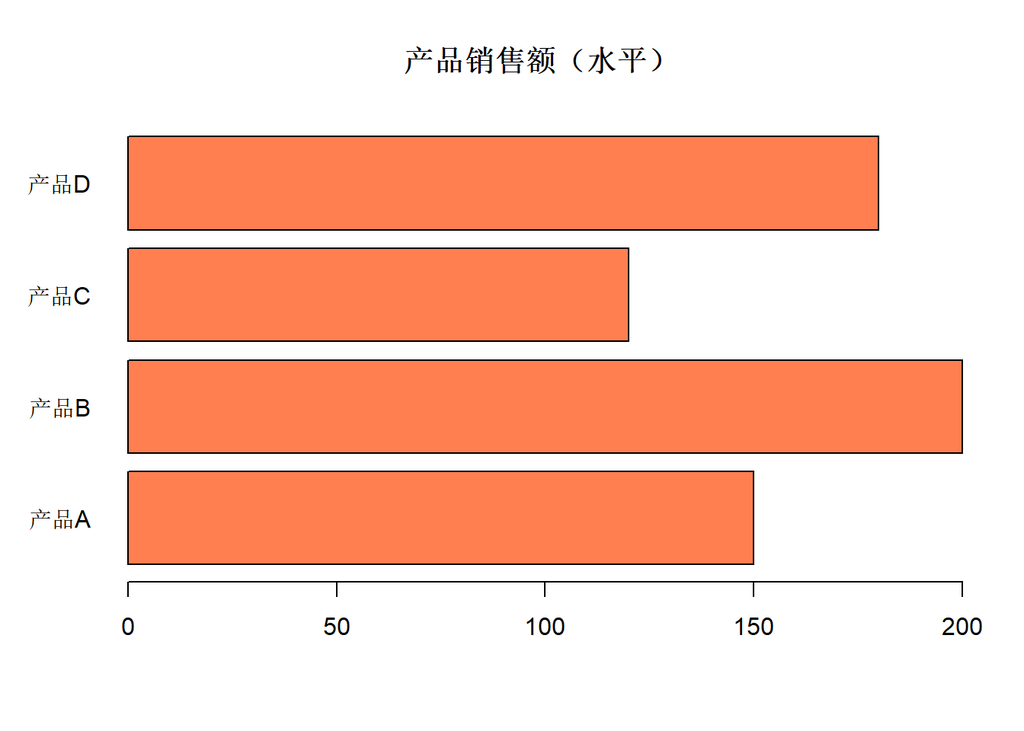

```r
# 水平柱状图
barplot(sales, names.arg = categories,
        main = "产品销售额（水平）",
        horiz = TRUE,           # 水平方向
        col = "coral",
        las = 1)                # 标签方向
```

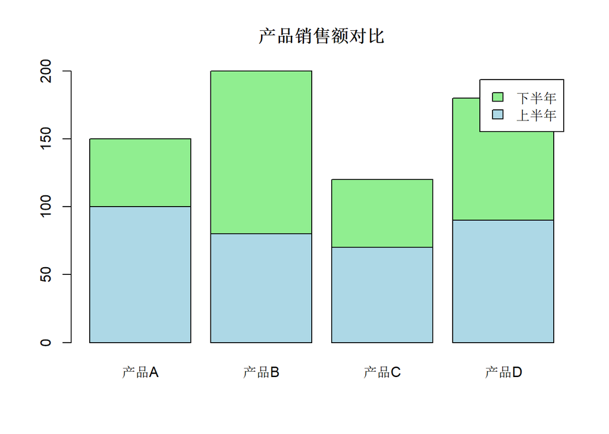

```r
# 堆叠柱状图
sales_matrix <- matrix(c(100, 80, 70, 90,
                         50, 120, 50, 90),
                       nrow = 2, byrow = TRUE)
rownames(sales_matrix) <- c("上半年", "下半年")
colnames(sales_matrix) <- categories

barplot(sales_matrix,
        main = "产品销售额对比",
        col = c("lightblue", "lightgreen"),
        legend.text = TRUE,
        beside = FALSE)  # beside=FALSE表示堆叠
```

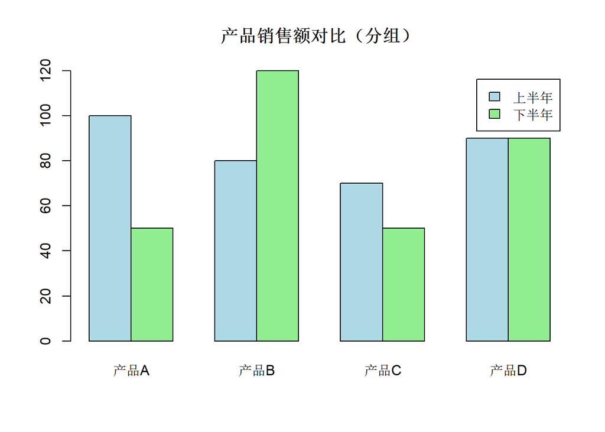

```r
# 分组柱状图
barplot(sales_matrix,
        main = "产品销售额对比（分组）",
        col = c("lightblue", "lightgreen"),
        legend.text = TRUE,
        beside = TRUE)  # beside=TRUE表示分组
```

### pie()函数

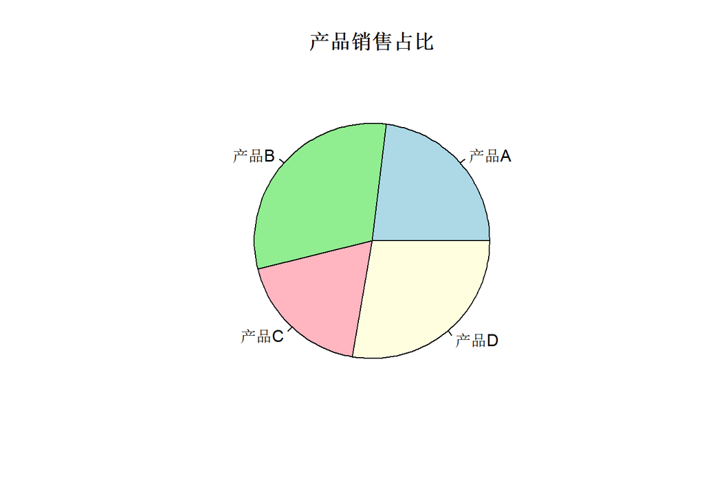

```r
# pie()绘制饼图

# 创建数据
categories <- c("产品A", "产品B", "产品C", "产品D")
sales <- c(150, 200, 120, 180)

# 基础饼图
pie(sales, labels = categories,
    main = "产品销售占比",
    col = c("lightblue", "lightgreen", "lightpink", "lightyellow"))
```

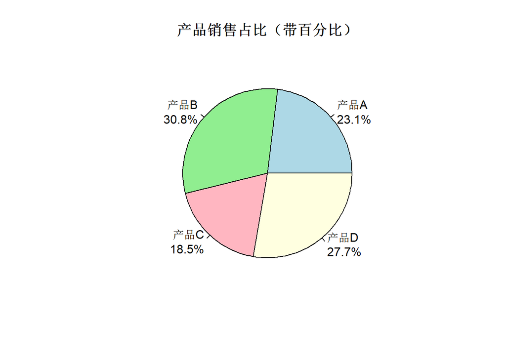

```r
# 显示百分比
percent <- round(sales / sum(sales) * 100, 1)
labels <- paste(categories, "\n", percent, "%", sep = "")
pie(sales, labels = labels,
    main = "产品销售占比（带百分比）",
    col = c("lightblue", "lightgreen", "lightpink", "lightyellow"))
```

**小结**：高级绘图函数创建新图形，常用参数包括main、xlab、ylab、col、pch等。

## 1.4 低级绘图函数

低级绘图函数在现有图形上添加元素。

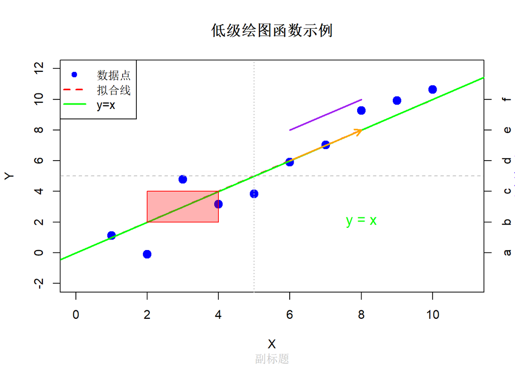

```r
# 创建基础图形
x <- 1:10
y <- x + rnorm(10)
plot(x, y, type = "n", main = "低级绘图函数示例",
     xlab = "X", ylab = "Y", xlim = c(0, 11), ylim = c(-2, 12))

# points()添加点
points(x, y, pch = 19, col = "blue", cex = 1.5)

# lines()添加线
lines(x, x, col = "red", lwd = 2, lty = 2)

# abline()添加直线
abline(a = 0, b = 1, col = "green", lwd = 2)  # y = x
abline(h = 5, col = "gray", lty = 2)          # 水平线
abline(v = 5, col = "gray", lty = 3)          # 垂直线

# text()添加文本
text(8, 2, "y = x", col = "green", cex = 1.2)

# legend()添加图例
legend("topleft",
       legend = c("数据点", "拟合线", "y=x"),
       col = c("blue", "red", "green"),
       pch = c(19, NA, NA),
       lty = c(NA, 2, 1),
       lwd = c(NA, 2, 2))

# title()添加标题（如果需要后加）
title(sub = "副标题", col.sub = "gray")

# axis()添加坐标轴
# 在右侧添加坐标轴
axis(4, at = seq(0, 10, 2), labels = letters[1:6])

# mtext()在边距添加文本
mtext("右侧标注", side = 4, line = 2, col = "blue")

# polygon()添加多边形
polygon(c(2, 4, 4, 2), c(2, 2, 4, 4),
        col = rgb(1, 0, 0, 0.3), border = "red")

# segments()添加线段
segments(6, 8, 8, 10, col = "purple", lwd = 2)

# arrows()添加箭头
arrows(6, 6, 8, 8, col = "orange", lwd = 2, length = 0.1)
```

**小结**：低级绘图函数可以灵活地在图形上添加各种元素。

## 1.5 图形参数设置

使用par()函数设置全局图形参数。

```r
# par()函数控制图形外观

# 查看当前参数设置
par("mfrow")    # 图形布局
```

```
## [1] 1 1
```

```r
par("mar")      # 图形边距
```

```
## [1] 5.1 4.1 4.1 2.1
```

```r
par("bg")       # 背景色
```

```
## [1] "white"
```

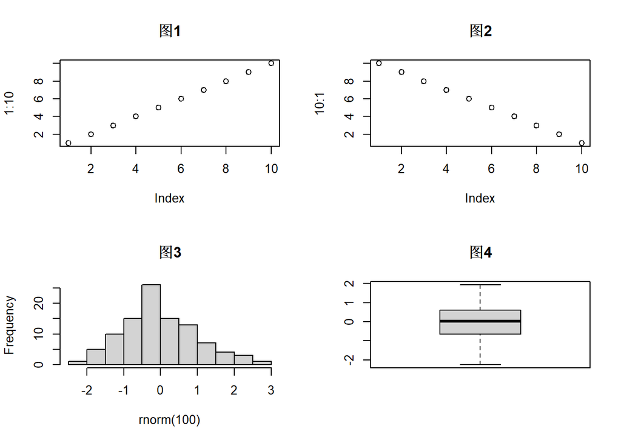

```r
# 设置多图布局
par(mfrow = c(2, 2))  # 2行2列

# 绘制4个图形
plot(1:10, main = "图1")
plot(10:1, main = "图2")
hist(rnorm(100), main = "图3")
boxplot(rnorm(100), main = "图4")
```

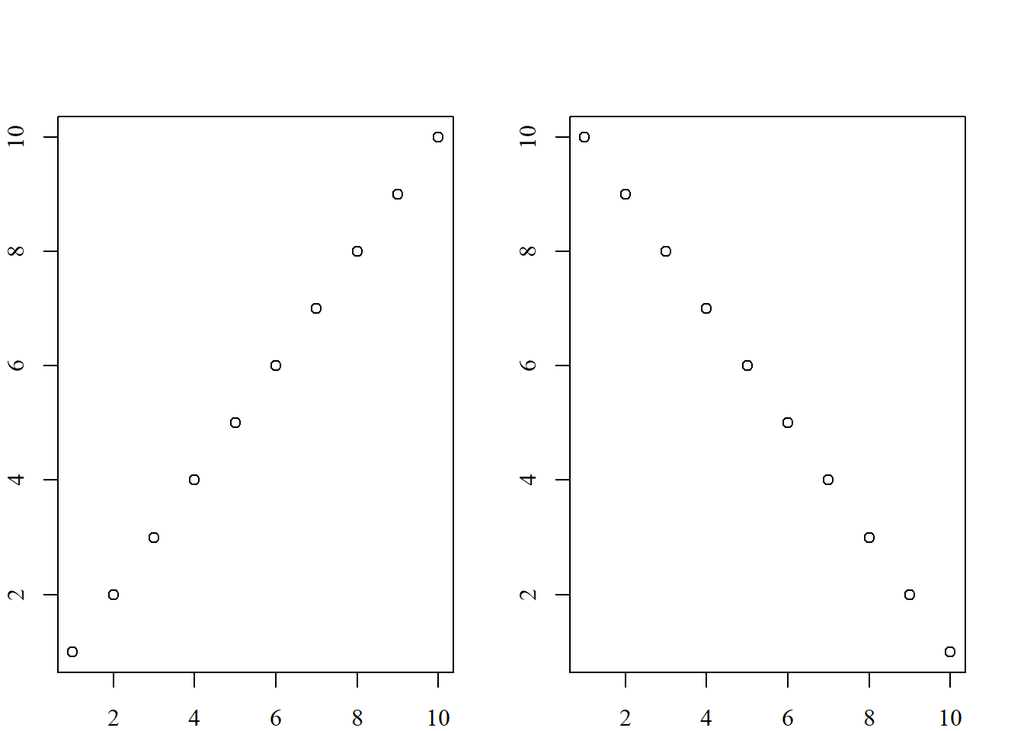

```r
# 恢复默认设置
par(mfrow = c(1, 1))

# 设置边距
par(mar = c(5, 4, 4, 2) + 0.1)  # 下、左、上、右
# 默认值：c(5, 4, 4, 2) + 0.1

# 设置外边距
par(oma = c(0, 0, 2, 0))  # 外边距

# 设置背景色
par(bg = "white")

# 设置字体大小
par(cex = 1.2)      # 全局放大
par(cex.axis = 1)   # 坐标轴
par(cex.lab = 1)    # 标签
par(cex.main = 1.2) # 标题

# 设置颜色
par(col = "black")       # 默认颜色
par(col.axis = "black")  # 坐标轴颜色
par(col.lab = "black")   # 标签颜色
par(col.main = "black")  # 标题颜色

# 设置字体
par(family = "serif")    # 衬线字体
# Windows下常用选项："serif", "sans", "mono"

# 保存当前参数设置
old_par <- par(no.readonly = TRUE)

# 修改参数
par(mfrow = c(1, 2), mar = c(2, 2, 2, 2))

# 绘制图形
plot(1:10)
plot(10:1)
```

```r
# 恢复原始参数
par(old_par)
```

**小结**：`par()`函数可以控制图形的各种全局参数，建议保存并恢复原始设置。

## 1.6 基础图形布局

使用layout()函数创建复杂布局。

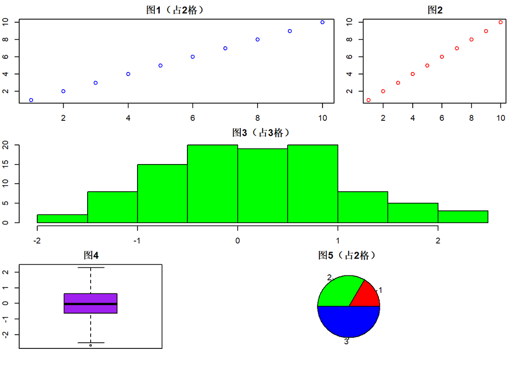

```r
# layout()函数创建自定义布局
# 注意：如果加载了plotly包，需要使用graphics::layout()避免冲突

# 定义布局矩阵
# 0表示该位置不放置图形
layout_matrix <- matrix(c(1, 1, 2,
                          3, 3, 3,
                          4, 5, 5), nrow = 3, byrow = TRUE)

# 应用布局（使用graphics::layout避免与plotly冲突）
graphics::layout(layout_matrix)

# 设置边距
par(mar = c(2, 2, 2, 1))

# 绘制图形
plot(1:10, main = "图1（占2格）", col = "blue")
plot(1:10, main = "图2", col = "red")
hist(rnorm(100), main = "图3（占3格）", col = "green")
boxplot(rnorm(50), main = "图4", col = "purple")
pie(c(1, 2, 3), main = "图5（占2格）", col = c("red", "green", "blue"))
```

```r
# 恢复默认布局
graphics::layout(1)
par(mar = c(5, 4, 4, 2) + 0.1)

# 查看布局
# layout.show(5)  # 显示5个区域的布局
```

**小结**：`layout()`比`par(mfrow)`更灵活，可以创建不规则布局。注意plotly包也有`layout()`函数，需使用`graphics::layout()`区分。

## 1.7 保存基础图形

将图形保存到文件。

```r
# 保存为PDF
pdf("my_plot.pdf", width = 8, height = 6)  # 打开PDF设备
plot(1:10, main = "保存的图形")             # 绘制图形
dev.off()                                   # 关闭设备

# 保存为PNG
png("my_plot.png", width = 800, height = 600, res = 100)
plot(1:10, main = "PNG图形")
dev.off()

# 保存为JPEG
jpeg("my_plot.jpg", width = 800, height = 600, quality = 90)
plot(1:10, main = "JPEG图形")
dev.off()

# 保存为SVG（矢量图）
svg("my_plot.svg", width = 8, height = 6)
plot(1:10, main = "SVG图形")
dev.off()

# 使用dev.copy()复制当前图形
plot(1:10, main = "当前图形")
dev.copy(pdf, "copied_plot.pdf")
dev.off()

# 查看当前设备
dev.cur()

# 查看所有设备
dev.list()
```

**小结**：矢量图（PDF、SVG）适合出版，位图（PNG、JPEG）适合网页。

## 1.8 基础绘图的局限性与转型至ggplot2

基础绘图系统有一些局限性，ggplot2提供了更优雅的解决方案。

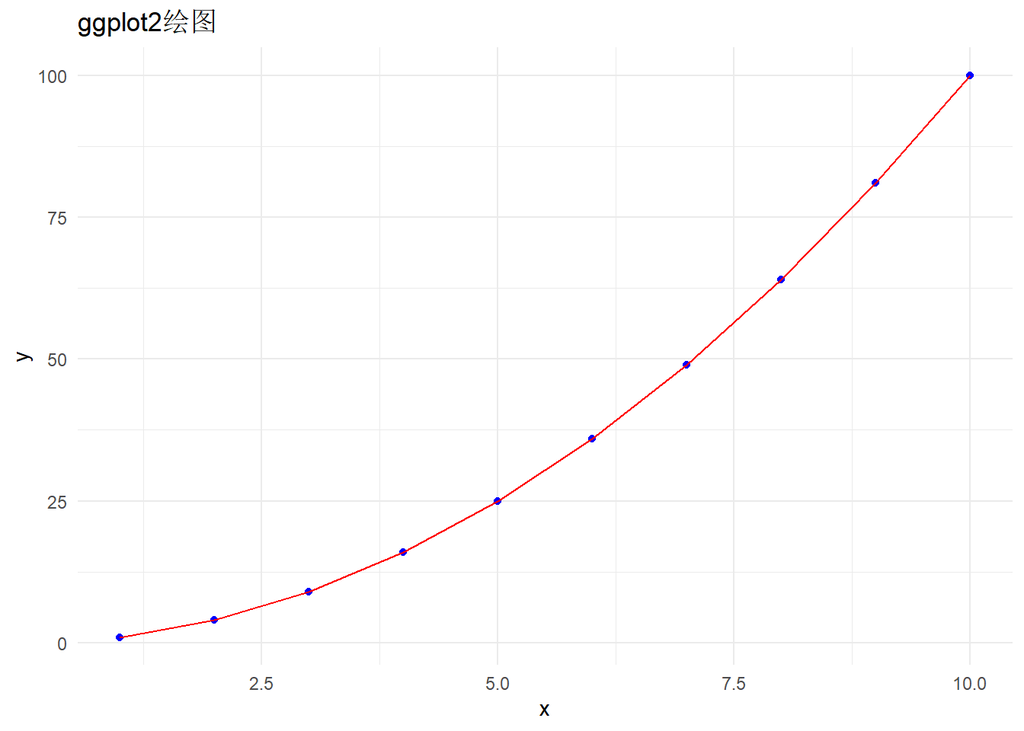

```r
# 基础绘图的局限性

# 1. 代码冗长
# 基础绘图需要手动添加每个元素
par(mfrow = c(1, 2))

# 基础绘图方式
plot(1:10, (1:10)^2, type = "n", main = "基础绘图")
points(1:10, (1:10)^2, pch = 19, col = "blue")
lines(1:10, (1:10)^2, col = "red")
legend("topleft", legend = c("点", "线"),
       pch = c(19, NA), lty = c(NA, 1),
       col = c("blue", "red"))

# ggplot2方式（更简洁）
library(ggplot2)
df <- data.frame(x = 1:10, y = (1:10)^2)
ggplot(df, aes(x = x, y = y)) +
  geom_point(color = "blue") +
  geom_line(color = "red") +
  ggtitle("ggplot2绘图") +
  theme_minimal()

par(mfrow = c(1, 1))
```

[output not shown]

```r
# 2. 分组处理复杂
# 基础绘图需要循环处理分组
# ggplot2自动处理分组

# 3. 分面困难
# 基础绘图需要手动创建多个面板
# ggplot2的facet功能自动处理

# 4. 主题不统一
# 基础绘图需要手动设置每个元素
# ggplot2有内置主题系统
```

**小结**：ggplot2语法更简洁、更一致，是现代R可视化的首选。

## 第一章总结

| 函数类型 | 函数 | 用途 |
| --- | --- | --- |
| 高级函数 | `plot()` | 通用绘图 |
| 高级函数 | `hist()` | 直方图 |
| 高级函数 | `boxplot()` | 箱线图 |
| 高级函数 | `barplot()` | 柱状图 |
| 高级函数 | `pie()` | 饼图 |
| 低级函数 | `points()` | 添加点 |
| 低级函数 | `lines()` | 添加线 |
| 低级函数 | `text()` | 添加文本 |
| 低级函数 | `legend()` | 添加图例 |
| 低级函数 | `abline()` | 添加直线 |
| 参数设置 | `par()` | 设置图形参数 |
| 布局 | `layout()` | 自定义布局 |

# 第二章：ggplot2绘图语法基础

ggplot2是R中最流行的可视化包，基于Leland Wilkinson的”图形语法”（Grammar of Graphics）理论。本章介绍ggplot2的核心概念和基本用法。

## 2.1 ggplot2的安装与加载

```r
# 安装ggplot2（如果尚未安装）
# install.packages("ggplot2")

# 加载ggplot2
library(ggplot2)

# ggplot2是tidyverse的一部分
# 也可以加载整个tidyverse
# library(tidyverse)

# 查看ggplot2版本
packageVersion("ggplot2")
```

```
## [1] '4.0.2'
```

**小结**：ggplot2可以单独加载，也可以作为tidyverse的一部分加载。

## 2.2 图形语法核心理念

图形语法将图形分解为独立的组件。

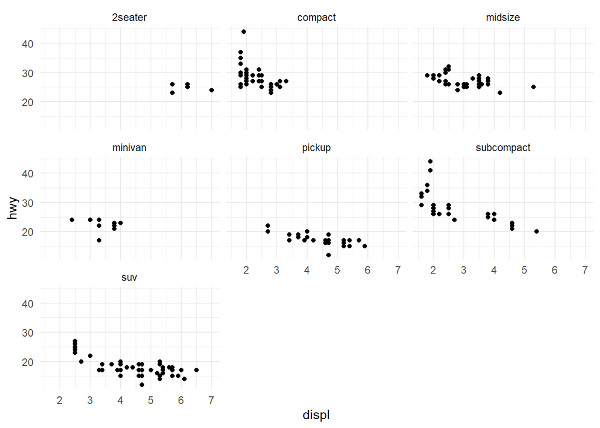

```r
# 图形语法的核心组件

# 1. 数据（Data）：要可视化的数据集
# 2. 映射（Aesthetics）：数据变量到图形属性的映射
# 3. 几何对象（Geometries）：图形的几何形状（点、线、柱等）
# 4. 标度（Scales）：控制图形属性的映射方式
# 5. 坐标系（Coordinates）：数据到平面的映射
# 6. 分面（Facets）：将数据分割成多个子图
# 7. 主题（Theme）：控制图形的非数据元素

# 示例：理解各组件
ggplot(data = mpg,                    # 数据
       aes(x = displ, y = hwy)) +     # 映射
  geom_point() +                       # 几何对象
  scale_x_continuous() +               # 标度
  coord_cartesian() +                  # 坐标系
  facet_wrap(~ class) +                # 分面
  theme_minimal()                      # 主题
```

**小结**：图形语法将图形分解为独立组件，每个组件都可以单独调整。